# Concrete Strength Prediction

```python
import pandas as pd
import numpy as np
import matplotlib.pyplot as plt
%matplotlib inline
# To enable plotting graphs in Jupyter notebook
import seaborn as sns

# Remove scientific notations and display numbers with 2 decimal points instead
pd.options.display.float_format = '{:,.2f}'.format
```

```python
df = pd.read_csv('concrete.csv')
```

```python
df
```

|  | cement | slag | ash | water | superplastic | coarseagg | fineagg | age | strength |
| --- | --- | --- | --- | --- | --- | --- | --- | --- | --- |
| 0 | 141.30 | 212.00 | 0.00 | 203.50 | 0.00 | 971.80 | 748.50 | 28 | 29.89 |
| 1 | 168.90 | 42.20 | 124.30 | 158.30 | 10.80 | 1,080.80 | 796.20 | 14 | 23.51 |
| 2 | 250.00 | 0.00 | 95.70 | 187.40 | 5.50 | 956.90 | 861.20 | 28 | 29.22 |
| 3 | 266.00 | 114.00 | 0.00 | 228.00 | 0.00 | 932.00 | 670.00 | 28 | 45.85 |
| 4 | 154.80 | 183.40 | 0.00 | 193.30 | 9.10 | 1,047.40 | 696.70 | 28 | 18.29 |
| ... | ... | ... | ... | ... | ... | ... | ... | ... | ... |
| 1025 | 135.00 | 0.00 | 166.00 | 180.00 | 10.00 | 961.00 | 805.00 | 28 | 13.29 |
| 1026 | 531.30 | 0.00 | 0.00 | 141.80 | 28.20 | 852.10 | 893.70 | 3 | 41.30 |
| 1027 | 276.40 | 116.00 | 90.30 | 179.60 | 8.90 | 870.10 | 768.30 | 28 | 44.28 |
| 1028 | 342.00 | 38.00 | 0.00 | 228.00 | 0.00 | 932.00 | 670.00 | 270 | 55.06 |
| 1029 | 540.00 | 0.00 | 0.00 | 173.00 | 0.00 | 1,125.00 | 613.00 | 7 | 52.61 |

1030 rows × 9 columns

```python
df.dtypes
```

```
cement          float64
slag            float64
ash             float64
water           float64
superplastic    float64
coarseagg       float64
fineagg         float64
age               int64
strength        float64
dtype: object
```

```python
df.describe()
```

|  | cement | slag | ash | water | superplastic | coarseagg | fineagg | age | strength |
| --- | --- | --- | --- | --- | --- | --- | --- | --- | --- |
| count | 1,030.00 | 1,030.00 | 1,030.00 | 1,030.00 | 1,030.00 | 1,030.00 | 1,030.00 | 1,030.00 | 1,030.00 |
| mean | 281.17 | 73.90 | 54.19 | 181.57 | 6.20 | 972.92 | 773.58 | 45.66 | 35.82 |
| std | 104.51 | 86.28 | 64.00 | 21.35 | 5.97 | 77.75 | 80.18 | 63.17 | 16.71 |
| min | 102.00 | 0.00 | 0.00 | 121.80 | 0.00 | 801.00 | 594.00 | 1.00 | 2.33 |
| 25% | 192.38 | 0.00 | 0.00 | 164.90 | 0.00 | 932.00 | 730.95 | 7.00 | 23.71 |
| 50% | 272.90 | 22.00 | 0.00 | 185.00 | 6.40 | 968.00 | 779.50 | 28.00 | 34.45 |
| 75% | 350.00 | 142.95 | 118.30 | 192.00 | 10.20 | 1,029.40 | 824.00 | 56.00 | 46.14 |
| max | 540.00 | 359.40 | 200.10 | 247.00 | 32.20 | 1,145.00 | 992.60 | 365.00 | 82.60 |

```python
df.info()
```

```
<class 'pandas.core.frame.DataFrame'>
RangeIndex: 1030 entries, 0 to 1029
Data columns (total 9 columns):
cement          1030 non-null float64
slag            1030 non-null float64
ash             1030 non-null float64
water           1030 non-null float64
superplastic    1030 non-null float64
coarseagg       1030 non-null float64
fineagg         1030 non-null float64
age             1030 non-null int64
strength        1030 non-null float64
dtypes: float64(8), int64(1)
memory usage: 72.5 KB
```

```python
df.skew()
```

```
cement          0.51
slag            0.80
ash             0.54
water           0.07
superplastic    0.91
coarseagg      -0.04
fineagg        -0.25
age             3.27
strength        0.42
dtype: float64
```

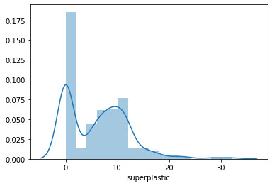

```python
sns.distplot(df['superplastic'])
```

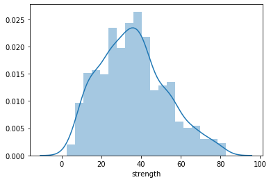

```python
sns.distplot(df['strength'])
```

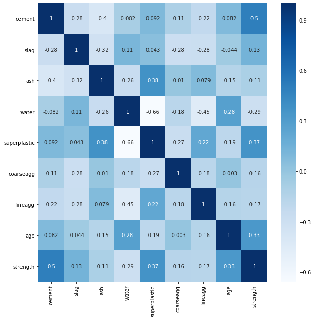

```python
corr = df.corr()
plt.figure(figsize=(10,10))

sns.heatmap(corr, annot=True, cmap='Blues')
plt.yticks(rotation=0)
plt.autoscale()
```

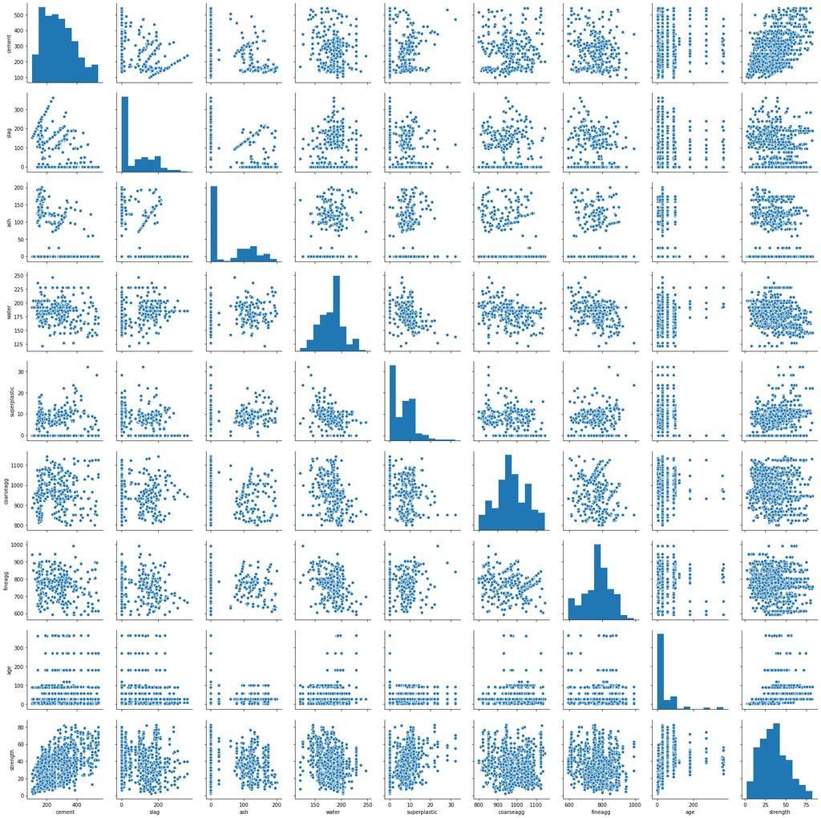

```python
sns.pairplot(df)
```

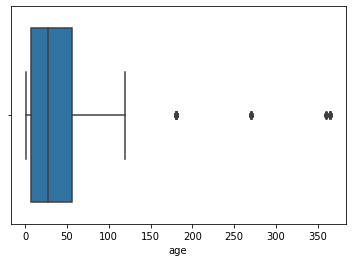

```python
sns.boxplot(df['age'])
```

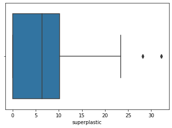

```python
sns.boxplot(df['superplastic'])
```

1) There is a high negative correlation between superplastic and water.

2) There is a positive correlations between Superplasticizer and Fly Ash, Fine Aggregate.

3) There is also positive correlation between Concrete compressive strength and Cement. Which is understandable as higher amount of cement contributes to the concrete strength.

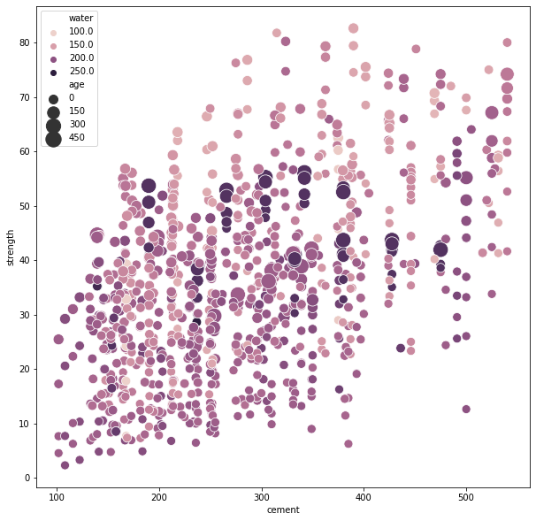

```python
plt.figure(figsize=(10,10))
sns.scatterplot(y="strength", x="cement", hue="water",size="age", data=df, sizes=(100, 300))

plt.autoscale()
```

Here we can see that:

1) The strength increases as the cement increases.

2) Strength increases as the age increases

3) Older cement needs more water to gain strength

4) Concrete strength is higher with less water.

5) If the cement age is less then more cement is required to gain strength

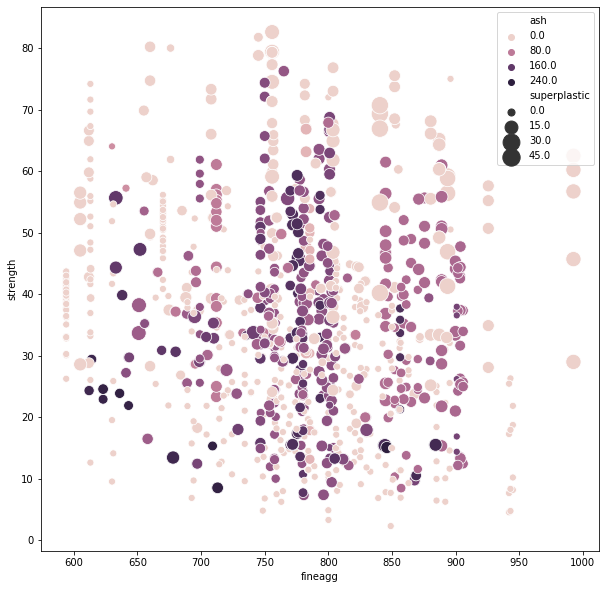

```python
plt.figure(figsize=(10,10))
plt.autoscale()
sns.scatterplot(y="strength", x="fineagg", hue="ash",
   size="superplastic", data=df, sizes=(50, 300))
```

From this graph we can infer that:

1) Compressive strength and Fly ash increases have negative correlation

2) Compressive strength and Superplasticizer have positive correlation

```python
X = df.iloc[:,:-1]
y = df.iloc[:,-1]
```

```python
from sklearn.model_selection import train_test_split
from sklearn.preprocessing import StandardScaler
X_train, X_test, y_train, y_test = train_test_split(X, y, test_size=0.2, random_state=2)
```

```python
sc = StandardScaler()
X_train = sc.fit_transform(X_train)
X_test = sc.transform(X_test)
```

```python
# Importing models
from sklearn.linear_model import LinearRegression, Lasso, Ridge
# Linear Regression
lr = LinearRegression()
# Lasso Regression
lasso = Lasso()
# Ridge Regression
ridge = Ridge()
# Fitting models on Training data
lr.fit(X_train, y_train)
lasso.fit(X_train, y_train)
ridge.fit(X_train, y_train)
# Making predictions on Test data
y_pred_lr = lr.predict(X_test)
y_pred_lasso = lasso.predict(X_test)
y_pred_ridge = ridge.predict(X_test)

from sklearn.metrics import mean_squared_error, mean_absolute_error, r2_score
print("Model\t\t\t RMSE \t\t R2")
print("""LinearRegression \t {:.2f} \t\t{:.2f}""".format(  np.sqrt(mean_squared_error(y_test, y_pred_lr)), r2_score(y_test, y_pred_lr)))
print("""LassoRegression \t {:.2f} \t\t{:.2f}""".format( np.sqrt(mean_squared_error(y_test, y_pred_lasso)), r2_score(y_test, y_pred_lasso)))
print("""RidgeRegression \t {:.2f} \t\t{:.2f}""".format( np.sqrt(mean_squared_error(y_test, y_pred_ridge)), r2_score(y_test, y_pred_ridge)))
```

```
Model			 RMSE 		 R2
LinearRegression 	 9.78 		0.69
LassoRegression 	 10.85 		0.62
RidgeRegression 	 9.79 		0.69
```

# Model And Feature selection

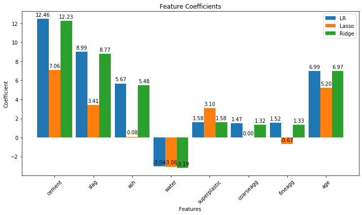

```python
coeff_lr = lr.coef_
coeff_lasso = lasso.coef_
coeff_ridge = ridge.coef_
labels = list(df.columns)[:-1]
x = np.arange(len(labels))
width = 0.3
fig, ax = plt.subplots(figsize=(10,6))
rects1 = ax.bar(x - 2*(width/2), coeff_lr, width, label='LR')
rects2 = ax.bar(x, coeff_lasso, width, label='Lasso')
rects3 = ax.bar(x + 2*(width/2), coeff_ridge, width, label='Ridge')
ax.set_ylabel('Coefficient')
ax.set_xlabel('Features')
ax.set_title('Feature Coefficients')
ax.set_xticks(x)
ax.set_xticklabels(labels, rotation=45)
ax.legend()
def autolabel(rects):
   """Attach a text label above each bar in *rects*, displaying its height."""
   for rect in rects:
      height = rect.get_height()
      ax.annotate('{:.2f}'.format(height), xy=(rect.get_x() + rect.get_width() / 2, height), xytext=(0, 3), textcoords="offset points", ha='center', va='bottom')
autolabel(rects1)
autolabel(rects2)
autolabel(rects3)
fig.tight_layout()
plt.show()
```

Here we can see that the lasso generalization technique has caused "Coarse Aggregate" to be zero and "Fly Ash" to be close to zero. So, if we decide to select Lasso regression for prediction, then we could drop these columns while performing model tuning. However, as per the results, R^2 is the lowest for Lasso regression.

Next we try to plot predicted vs actual values to see if the linear model would be a good choice.

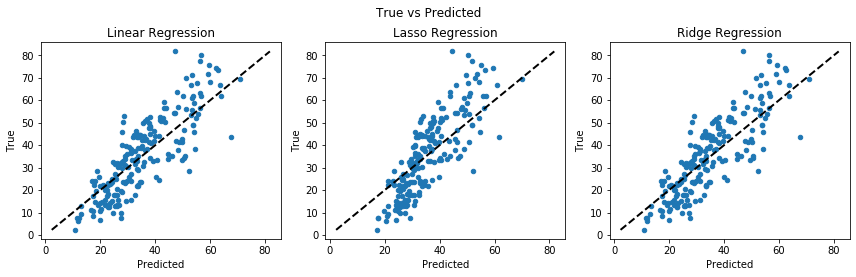

```python
fig, (ax1, ax2, ax3) = plt.subplots(1,3, figsize=(12,4))
ax1.scatter(y_pred_lr, y_test, s=20)
ax1.plot([y_test.min(), y_test.max()], [y_test.min(), y_test.max()], 'k--', lw=2)
ax1.set_ylabel("True")
ax1.set_xlabel("Predicted")
ax1.set_title("Linear Regression")
ax2.scatter(y_pred_lasso, y_test, s=20)
ax2.plot([y_test.min(), y_test.max()], [y_test.min(), y_test.max()], 'k--', lw=2)
ax2.set_ylabel("True")
ax2.set_xlabel("Predicted")
ax2.set_title("Lasso Regression")
ax3.scatter(y_pred_ridge, y_test, s=20)
ax3.plot([y_test.min(), y_test.max()], [y_test.min(), y_test.max()], 'k--', lw=2)
ax3.set_ylabel("True")
ax3.set_xlabel("Predicted")
ax3.set_title("Ridge Regression")
fig.suptitle("True vs Predicted")
fig.tight_layout(rect=[0, 0.03, 1, 0.95])
```

Since, the R^2 even for ridge and linear regression was 0.69 and that is also show in the graphs above that the information is not captured accurately. Next we try regression models with higher degree of polynomials.

```python
from sklearn.preprocessing import PolynomialFeatures
from sklearn import model_selection

train_scores=[]
test_scores=[]
for deg in [1,2,3,4]:
    poly = PolynomialFeatures( degree = deg, include_bias = False)
    xPoly_train = poly.fit_transform(X_train)
    xPoly_test = poly.fit_transform(X_test)
    regression_modelPoly = lr.fit(xPoly_train, y_train)

    train_scores.append(regression_modelPoly.score(xPoly_train, y_train))
    test_scores.append(regression_modelP2.score(xPoly_test, y_test))
```

```python
print(train_scores,test_scores)
```

```
[0.5938105019500771, 0.8020637910695443, 0.9231020983898489, 0.9823489675102808] [0.6881335032057954, 0.8338045394499826, 0.9171681246501135, -3.357030293290105]
```

```python
dat = {'Train Scores':train_scores, 'Test Scores':test_scores}
res = pd.DataFrame(index=[1,2,3,4],data=dat)
```

```python
res
```

|  | Train Scores | Test Scores |
| --- | --- | --- |
| 1 | 0.59 | 0.69 |
| 2 | 0.80 | 0.83 |
| 3 | 0.92 | 0.92 |
| 4 | 0.98 | -3.36 |

So, from this table we can depict that degree 3 polynomials has the best result with minimum bias. Now we will try the polynomial data with Cross Validation to simulate how the model could work in production environment.

```python
from sklearn import model_selection
poly = PolynomialFeatures( degree = 3, include_bias = False)
xPoly_train = poly.fit_transform(X_train)

avg_r2_list = []
seed = 6
kfold = model_selection.KFold(n_splits=10, random_state=seed)
lr_cv = LinearRegression()

stats = model_selection.cross_val_score(lr_cv, xPoly_train, y_train, scoring='r2', cv=kfold)
avg_r2 = stats.sum()/len(stats)
avg_r2_list.append(avg_r2)
```

```python
# confidence intervals
alpha = 0.95                             # for 95% confidence
p = ((1.0-alpha)/2.0) * 100              # tail regions on right and left .25 on each side indicated by P value (border)
lower = max(0.0, np.percentile(stats, p))
p = (alpha+((1.0-alpha)/2.0)) * 100
upper = min(1.0, np.percentile(stats, p))
txt = 'With {alpha:.2f}% confidence, the R^2 of the model is in the range of '

print('%.1f confidence interval is %.1f%% and %.1f%%' % (alpha*100, lower*100, upper*100))
print('Average R2 value of Decision Tree={avg_r2:.2f}'.format(avg_r2=avg_r2))
```

```
95.0 confidence interval is 65.7% and 86.7%
Average R2 value of Decision Tree=0.81
```

Since our objective was to obtain a 80-95% of R2 Score, the linear regression model even with 3 degree polynomial does not seem to be a good choice.

Let's try Decision Tree and see how that performs.

```python
dt_cv = DecisionTreeRegressor()
stats = model_selection.cross_val_score(dt_cv, X_train, y_train, scoring='r2', cv=kfold)
avg_r2 = stats.sum()/len(stats)
avg_r2_list.append(avg_r2)
```

```python
# confidence intervals
alpha = 0.95                             # for 95% confidence
p = ((1.0-alpha)/2.0) * 100              # tail regions on right and left .25 on each side indicated by P value (border)
lower = max(0.0, np.percentile(stats, p))
p = (alpha+((1.0-alpha)/2.0)) * 100
upper = min(1.0, np.percentile(stats, p))
txt = 'With {alpha:.2f}% confidence, the R^2 of the model is in the range of '

print('%.1f confidence interval is %.1f%% and %.1f%%' % (alpha*100, lower*100, upper*100))
print('Average R2 value of Decision Tree={avg_r2:.2f}'.format(avg_r2=avg_r2))
```

```
95.0 confidence interval is 75.6% and 87.5%
Average R2 value of Decision Tree=0.82
```

Here, we see a little improvement but still the R2 range in less than our target R2 range i.e. 80-95%.

Lets try ensemble models and see how they perform.

```python
from sklearn.ensemble import RandomForestRegressor
rfr = RandomForestRegressor(n_estimators=10)
stats = model_selection.cross_val_score(rfr, X_train, y_train, scoring='r2', cv=kfold)
avg_r2 = stats.sum()/len(stats)
avg_r2_list.append(avg_r2)
# confidence intervals
alpha = 0.95                             # for 95% confidence
p = ((1.0-alpha)/2.0) * 100              # tail regions on right and left .25 on each side indicated by P value (border)
lower = max(0.0, np.percentile(stats, p))
p = (alpha+((1.0-alpha)/2.0)) * 100
upper = min(1.0, np.percentile(stats, p))
txt = 'With {alpha:.2f}% confidence, the R^2 of the model is in the range of '

print('%.1f confidence interval is %.1f%% and %.1f%%' % (alpha*100, lower*100, upper*100))
print('Average R2 value of Random Forest={avg_r2:.2f}'.format(avg_r2=avg_r2))
```

```
95.0 confidence interval is 80.8% and 93.6%
Average R2 value of Random Forest=0.88
```

Let's see how these models perform on Test Data Set.

Average R2 values of all three models are given as below table.

```python
res_cv = {'Average R2 Scores in Cross Validation':avg_r2_list}
cv_df = pd.DataFrame(data=res_cv,index=['Linear Regression','Decision Tree','Random Forest'])
cv_df
```

|  | Average R2 Scores in Cross Validation |
| --- | --- |
| Linear Regression | 0.81 |
| Decision Tree | 0.82 |
| Random Forest | 0.88 |

```python
rfr.fit(X_train,y_train)
dt_cv.fit(X_train,y_train)
lr_cv.fit(xPoly_train,y_train)

rfr_predict = rfr.predict(X_test)
rfr_score = r2_score(y_test,rfr_predict)

dt_predict = dt_cv.predict(X_test)
dt_score = r2_score(y_test,dt_predict)

xPoly_test = poly.fit_transform(X_test)
lr_predict = lr_cv.predict(xPoly_test)
lr_score = r2_score(y_test,lr_predict)

r2_res = [lr_score, dt_score, rfr_score]

res_test = {'R2 Scores on Test':r2_res}
test_res_df = pd.DataFrame(data=res_test,index=['Linear Regression','Decision Tree','Random Forest'])
test_res_df
```

|  | R2 Scores on Test |
| --- | --- |
| Linear Regression | 0.92 |
| Decision Tree | 0.88 |
| Random Forest | 0.92 |

On the test data Linear Regression got 92% R2 Score. However, we cannot expect such performance in production because scores with cross validation varied largely.

```python
param_dist = {"max_depth": [3, 10,None],
              "max_features": sp_randint(1, rfr.n_features_),
              "min_samples_split": sp_randint(2, 11),
              "min_samples_leaf": sp_randint(1, 11),
              "bootstrap": [True, False],
              "criterion": ['mse', 'mae']}
```

```python
from scipy.stats import randint as sp_randint
from sklearn.model_selection import GridSearchCV
from sklearn.model_selection import RandomizedSearchCV
from sklearn.datasets import load_digits
# run randomized search
samples = 10  # number of random samples
randomCV = RandomizedSearchCV(rfr, param_distributions=param_dist, n_iter=samples, cv=10)
```

```python
randomCV.fit(X_train, y_train)
```

```
RandomizedSearchCV(cv=10, error_score='raise-deprecating',
                   estimator=RandomForestRegressor(bootstrap=True,
                                                   criterion='mse',
                                                   max_depth=None,
                                                   max_features='auto',
                                                   max_leaf_nodes=None,
                                                   min_impurity_decrease=0.0,
                                                   min_impurity_split=None,
                                                   min_samples_leaf=1,
                                                   min_samples_split=2,
                                                   min_weight_fraction_leaf=0.0,
                                                   n_estimators=10, n_jobs=None,
                                                   oob_score=False,
                                                   random_state=...
                                        'max_features': <scipy.stats._distn_infrastructure.rv_frozen object at 0x0000027037BFFC08>,
                                        'min_samples_leaf': <scipy.stats._distn_infrastructure.rv_frozen object at 0x000002703E694108>,
                                        'min_samples_split': <scipy.stats._distn_infrastructure.rv_frozen object at 0x000002703560E908>},
                   pre_dispatch='2*n_jobs', random_state=None, refit=True,
                   return_train_score=False, scoring=None, verbose=0)
```

```python
randomCV.best_params_
```

```
{'bootstrap': False,
 'criterion': 'mae',
 'max_depth': 10,
 'max_features': 4,
 'min_samples_leaf': 1,
 'min_samples_split': 6}
```

```python
best_param_rf = RandomForestRegressor(n_estimators=100,bootstrap= False,
 criterion = 'mse',
 max_depth= 10,
 max_features= 4,
 min_samples_leaf= 1,
 min_samples_split= 6)
```

```python
stats = model_selection.cross_val_score(best_param_rf, X_train, y_train, scoring='r2', cv=kfold)
avg_r2 = stats.sum()/len(stats)

# confidence intervals
alpha = 0.95                             # for 95% confidence
p = ((1.0-alpha)/2.0) * 100              # tail regions on right and left .25 on each side indicated by P value (border)
lower = max(0.0, np.percentile(stats, p))
p = (alpha+((1.0-alpha)/2.0)) * 100
upper = min(1.0, np.percentile(stats, p))
txt = 'With {alpha:.2f}% confidence, the R^2 of the model is in the range of '

print('%.1f confidence interval is %.1f%% and %.1f%%' % (alpha*100, lower*100, upper*100))
print('Average R2 value of Random Forest={avg_r2:.2f}'.format(avg_r2=avg_r2*100))

hyper_param_results={}
hyper_param_results = {'Average CV R2 Value':[round(avg_r2*100,2)]}
best_param_rf.fit(X_train,y_train)
test_score_rf = best_param_rf.score(X_test,y_test)
hyper_param_results['Test R2 Result'] = [round(test_score_rf*100,2)]
hyper_param_results['95.0 confidence interval'] = ['%.1f%% and %.1f%%'% (lower*100, upper*100)]
```

```
95.0 confidence interval is 82.7% and 93.2%
Average R2 value of Random Forest=89.44
```

Since RandomForest is an ensembled form of Decision Tree, so there is no point in performing hyperparameter tuning for Decicion Tree. Hence, we are going to try hyper parameter tuning for Linear regression.

```python
lr_hyper = LinearRegression()
param_dist_lr = {'copy_X': [True,False], 'fit_intercept': [True,False],  'normalize': [False, True]}
randomCV_lr = RandomizedSearchCV(lr_hyper, param_distributions=param_dist_lr, n_iter=samples, cv=10)
randomCV_lr.fit(xPoly_train, y_train)
randomCV_lr.best_params_
```

```
{'normalize': False, 'fit_intercept': True, 'copy_X': True}
```

These are basically the default parameters of Linear Regression

```python
lr_hyper = LinearRegression(normalize=False, fit_intercept= True, copy_X = True)
```

```python
stats = model_selection.cross_val_score(lr_hyper, xPoly_train, y_train, scoring='r2', cv=kfold)
avg_r2 = stats.sum()/len(stats)

# confidence intervals
alpha = 0.95                             # for 95% confidence
p = ((1.0-alpha)/2.0) * 100              # tail regions on right and left .25 on each side indicated by P value (border)
lower = max(0.0, np.percentile(stats, p))
p = (alpha+((1.0-alpha)/2.0)) * 100
upper = min(1.0, np.percentile(stats, p))
txt = 'With {alpha:.2f}% confidence, the R^2 of the model is in the range of '

print('%.1f confidence interval is %.1f%% and %.1f%%' % (alpha*100, lower*100, upper*100))
print('Average R2 value of Linear Regression={avg_r2:.2f}'.format(avg_r2=avg_r2*100))

hyper_param_results['Average CV R2 Value'].append(round(avg_r2*100,2))
lr_hyper.fit(X_train,y_train)
test_score_rf = lr_hyper.score(X_test,y_test)
hyper_param_results['Test R2 Result'].append(round(test_score_rf*100,2))
hyper_param_results['95.0 confidence interval'].append('%.1f%% and %.1f%%'% (lower*100, upper*100))
```

```
95.0 confidence interval is 65.7% and 86.7%
Average R2 value of Linear Regression=80.79
```

```python
hyper_param_results
```

```
{'Average CV R2 Value': [89.44, 80.79],
 'Test R2 Result': [92.51, 68.81],
 '95.0 confidence interval': ['82.7% and 93.2%', '65.7% and 86.7%']}
```

```python
hyperpara_resultdf = pd.DataFrame(data=hyper_param_results,index=['Random Forest','Linear Regression'])
hyperpara_resultdf

print('Model Comparison after Hyper Parameter Tuning')
hyperpara_resultdf
```

```
Model Comparison after Hyper Parameter Tuning
```

|  | Average CV R2 Value | Test R2 Result | 95.0 confidence interval |
| --- | --- | --- | --- |
| Random Forest | 89.44 | 92.51 | 82.7% and 93.2% |
| Linear Regression | 80.79 | 68.81 | 65.7% and 86.7% |